# Applying Machine Learning to the Housing Market:

## An Analysis of Housing Price Predictions

One potential idea for using machine learning to analyze and build models for business problems on a housing dataset could be to predict housing prices based on various features of the properties. This could be useful for real estate companies, property tax purposes, investors, and home buyers/sellers to make informed decisions about the housing market.

The first step in this process would be to gather and clean the housing dataset. This would involve collecting data on various features of the properties such as location, size, number of bedrooms and bathrooms, age of the property, and any additional amenities. The data would then need to be preprocessed to ensure that it is in a format suitable for analysis.

Once the data is prepared, various machine learning algorithms could be applied to build predictive models. For example, regression analysis could be used to predict the price of a property based on its features. Decision trees or random forests could also be used to identify the most important features that affect housing prices.

The resulting models could then be used by real estate companies and investors to make informed decisions about buying or selling properties. Home buyers and sellers could also use the models to estimate the value of their property and make decisions about whether to buy or sell.

Overall, machine learning has the potential to provide valuable insights and solutions for business problems in the housing market. By using advanced algorithms and techniques, companies and individuals can make more informed decisions and improve their operations.

## Obtain Housing Datasets

Data reference 1 : https://github.com/ageron/data/blob/main/housing.tgz

Data reference 2 : https://www.dcc.fc.up.pt/~ltorgo/Regression/cal_housing.html

Data reference 3 : https://www.kaggle.com/datasets/vikrishnan/boston-house-prices

```python
import os
import opendatasets as od
import shutil

import pandas as pd
import numpy as np
%matplotlib inline
import matplotlib.pyplot as plt
```

### Import data reference 1

```python
folder_path = os.path.join('datasets', 'housing')
file_name = 'housing.csv'
file_path = os.path.join(folder_path, file_name)
```

```python
root_url = 'https://raw.githubusercontent.com/ageron/data/main/housing/'
file_url = os.path.join(root_url, file_name)
od.download(file_url)
```

```
Downloading https://raw.githubusercontent.com/ageron/data/main/housing/housing.csv to .\housing.csv
```

```
1425408it [00:00, 26631066.23it/s]
```

```python
shutil.move(file_name, file_path)
```

```
'datasets\\housing\\housing.csv'
```

```python
housing = pd.read_csv(file_path)
```

## Exploratory Data Anlysis

```python
housing.head()
```

|  | longitude | latitude | housing_median_age | total_rooms | total_bedrooms | population | households | median_income | median_house_value | ocean_proximity |
| --- | --- | --- | --- | --- | --- | --- | --- | --- | --- | --- |
| 0 | -122.23 | 37.88 | 41.0 | 880.0 | 129.0 | 322.0 | 126.0 | 8.3252 | 452600.0 | NEAR BAY |
| 1 | -122.22 | 37.86 | 21.0 | 7099.0 | 1106.0 | 2401.0 | 1138.0 | 8.3014 | 358500.0 | NEAR BAY |
| 2 | -122.24 | 37.85 | 52.0 | 1467.0 | 190.0 | 496.0 | 177.0 | 7.2574 | 352100.0 | NEAR BAY |
| 3 | -122.25 | 37.85 | 52.0 | 1274.0 | 235.0 | 558.0 | 219.0 | 5.6431 | 341300.0 | NEAR BAY |
| 4 | -122.25 | 37.85 | 52.0 | 1627.0 | 280.0 | 565.0 | 259.0 | 3.8462 | 342200.0 | NEAR BAY |

Looking at the dataset, all columns are numeric except for ocean_proximity which is categorical. The list of categories and thier counts are shown below:

```python
housing.info()
```

```
<class 'pandas.core.frame.DataFrame'>
RangeIndex: 20640 entries, 0 to 20639
Data columns (total 10 columns):
 #   Column              Non-Null Count  Dtype
---  ------              --------------  -----
 0   longitude           20640 non-null  float64
 1   latitude            20640 non-null  float64
 2   housing_median_age  20640 non-null  float64
 3   total_rooms         20640 non-null  float64
 4   total_bedrooms      20433 non-null  float64
 5   population          20640 non-null  float64
 6   households          20640 non-null  float64
 7   median_income       20640 non-null  float64
 8   median_house_value  20640 non-null  float64
 9   ocean_proximity     20640 non-null  object
dtypes: float64(9), object(1)
memory usage: 1.6+ MB
```

```python
housing.ocean_proximity.value_counts()
```

```
<1H OCEAN     9136
INLAND        6551
NEAR OCEAN    2658
NEAR BAY      2290
ISLAND           5
Name: ocean_proximity, dtype: int64
```

```python
housing.describe()
```

|  | longitude | latitude | housing_median_age | total_rooms | total_bedrooms | population | households | median_income | median_house_value |
| --- | --- | --- | --- | --- | --- | --- | --- | --- | --- |
| count | 20640.000000 | 20640.000000 | 20640.000000 | 20640.000000 | 20433.000000 | 20640.000000 | 20640.000000 | 20640.000000 | 20640.000000 |
| mean | -119.569704 | 35.631861 | 28.639486 | 2635.763081 | 537.870553 | 1425.476744 | 499.539680 | 3.870671 | 206855.816909 |
| std | 2.003532 | 2.135952 | 12.585558 | 2181.615252 | 421.385070 | 1132.462122 | 382.329753 | 1.899822 | 115395.615874 |
| min | -124.350000 | 32.540000 | 1.000000 | 2.000000 | 1.000000 | 3.000000 | 1.000000 | 0.499900 | 14999.000000 |
| 25% | -121.800000 | 33.930000 | 18.000000 | 1447.750000 | 296.000000 | 787.000000 | 280.000000 | 2.563400 | 119600.000000 |
| 50% | -118.490000 | 34.260000 | 29.000000 | 2127.000000 | 435.000000 | 1166.000000 | 409.000000 | 3.534800 | 179700.000000 |
| 75% | -118.010000 | 37.710000 | 37.000000 | 3148.000000 | 647.000000 | 1725.000000 | 605.000000 | 4.743250 | 264725.000000 |
| max | -114.310000 | 41.950000 | 52.000000 | 39320.000000 | 6445.000000 | 35682.000000 | 6082.000000 | 15.000100 | 500001.000000 |

```python
housing.median()
```

```
longitude               -118.4900
latitude                  34.2600
housing_median_age        29.0000
total_rooms             2127.0000
total_bedrooms           435.0000
population              1166.0000
households               409.0000
median_income              3.5348
median_house_value    179700.0000
dtype: float64
```

There are some missing values in total_bedrooms columns

Median_income is in tens of thousands dollars. The median income is thus $35,348.

```python
housing.count()
```

```
longitude             20640
latitude              20640
housing_median_age    20640
total_rooms           20640
total_bedrooms        20433
population            20640
households            20640
median_income         20640
median_house_value    20640
ocean_proximity       20640
dtype: int64
```

```
array([[<AxesSubplot:title={'center':'longitude'}>,
        <AxesSubplot:title={'center':'latitude'}>,
        <AxesSubplot:title={'center':'housing_median_age'}>],
       [<AxesSubplot:title={'center':'total_rooms'}>,
        <AxesSubplot:title={'center':'total_bedrooms'}>,
        <AxesSubplot:title={'center':'population'}>],
       [<AxesSubplot:title={'center':'households'}>,
        <AxesSubplot:title={'center':'median_income'}>,
        <AxesSubplot:title={'center':'median_house_value'}>]],
      dtype=object)
```

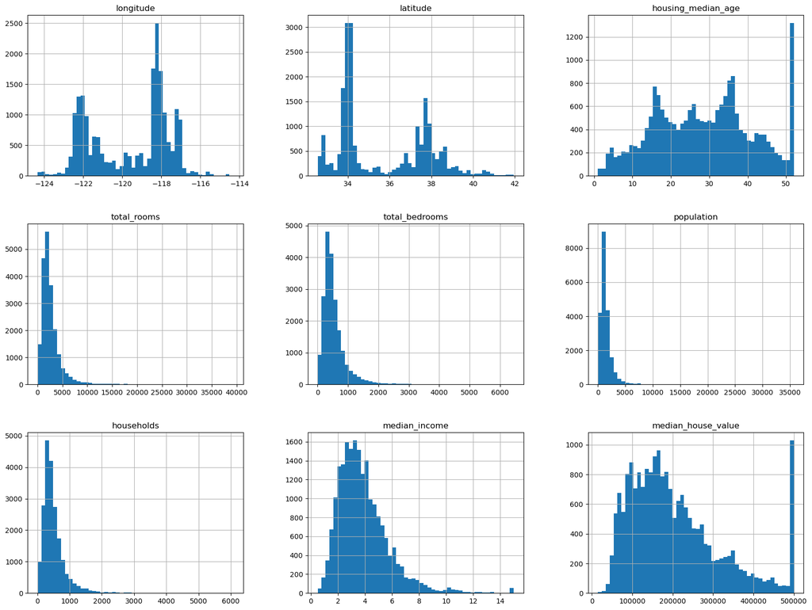

```python
housing.hist(bins=50, figsize=(20,15))
```

Looking at the histogram, at glance the data is skewed to the right, meaning mean > mode. Outliers can cause an issue when training ML algorithm.

```python
corr_matrix = housing.corr()
```

```python
print(corr_matrix)
```

```
                    longitude  latitude  housing_median_age  total_rooms  \
longitude            1.000000 -0.924664           -0.108197     0.044568
latitude            -0.924664  1.000000            0.011173    -0.036100
housing_median_age  -0.108197  0.011173            1.000000    -0.361262
total_rooms          0.044568 -0.036100           -0.361262     1.000000
total_bedrooms       0.069608 -0.066983           -0.320451     0.930380
population           0.099773 -0.108785           -0.296244     0.857126
households           0.055310 -0.071035           -0.302916     0.918484
median_income       -0.015176 -0.079809           -0.119034     0.198050
median_house_value  -0.045967 -0.144160            0.105623     0.134153

                    total_bedrooms  population  households  median_income  \
longitude                 0.069608    0.099773    0.055310      -0.015176
latitude                 -0.066983   -0.108785   -0.071035      -0.079809
housing_median_age       -0.320451   -0.296244   -0.302916      -0.119034
total_rooms               0.930380    0.857126    0.918484       0.198050
total_bedrooms            1.000000    0.877747    0.979728      -0.007723
population                0.877747    1.000000    0.907222       0.004834
households                0.979728    0.907222    1.000000       0.013033
median_income            -0.007723    0.004834    0.013033       1.000000
median_house_value        0.049686   -0.024650    0.065843       0.688075

                    median_house_value
longitude                    -0.045967
latitude                     -0.144160
housing_median_age            0.105623
total_rooms                   0.134153
total_bedrooms                0.049686
population                   -0.024650
households                    0.065843
median_income                 0.688075
median_house_value            1.000000
```

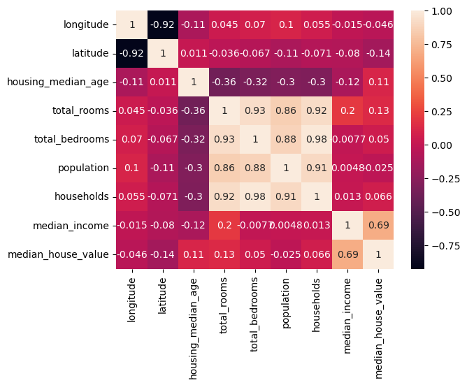

```python
import seaborn as sns
sns.heatmap(corr_matrix, annot=True)
plt.show()
```

There are some variables that are highly correlated. For example, the correlation between total_bedrooms and households is 0.98. That means when there is additioanl household member, it is likely for the total number of bedroom increase by 1. In this case we might want to consider removing one of those two variables.

total_rooms and total_berooms are also highly correlated, thus that leads to total_room and households are highly correlated.

```python
longitude = housing['longitude']
latitude = housing['latitude']
housing_median_age = housing['housing_median_age']
total_rooms = housing['total_rooms']
total_bedrooms = housing['total_bedrooms']
population = housing['population']
households = housing['households']
median_income = housing['median_income']
median_house_value = housing['median_house_value']
```

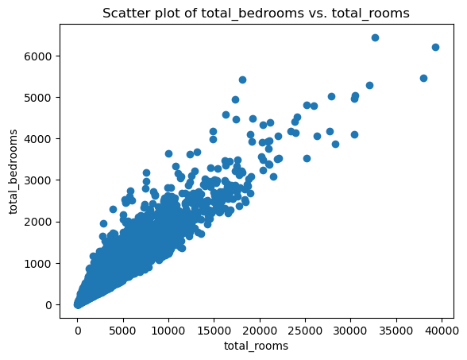

```python
import matplotlib.pyplot as plt
import pandas as pd

plt.scatter(total_rooms, total_bedrooms)

plt.xlabel('total_rooms')
plt.ylabel('total_bedrooms')
plt.title('Scatter plot of total_bedrooms vs. total_rooms')
plt.show()
```

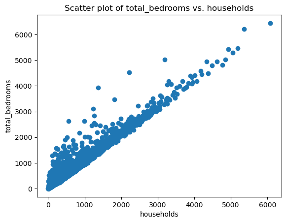

```python
plt.scatter(households, total_bedrooms)

plt.xlabel('households')
plt.ylabel('total_bedrooms')
plt.title('Scatter plot of total_bedrooms vs. households')
plt.show()
```

Which feature will better explain the price of house?

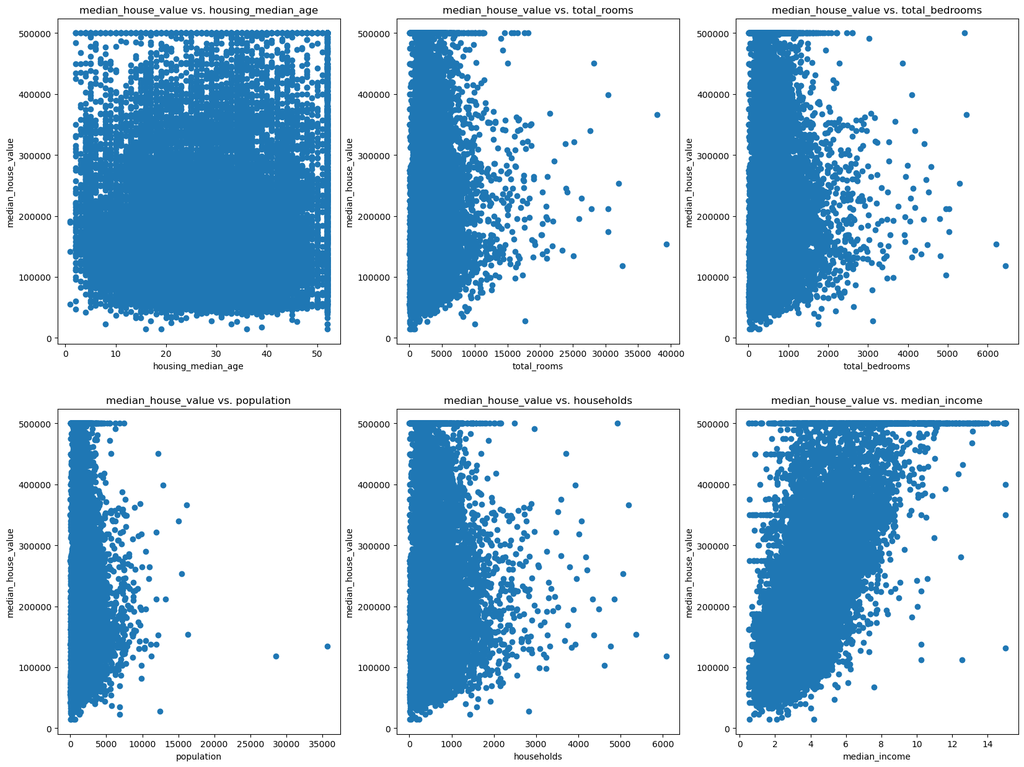

```python
fig, axs = plt.subplots(2, 3, figsize=(20,15))

axs[0,0].scatter(housing_median_age, median_house_value)
axs[0,1].scatter(total_rooms, median_house_value)
axs[0,2].scatter(total_bedrooms , median_house_value)
axs[1,0].scatter(population, median_house_value)
axs[1,1].scatter(households, median_house_value)
axs[1,2].scatter(median_income, median_house_value)

axs[0,0].set_title('median_house_value vs. housing_median_age')
axs[0,0].set_xlabel('housing_median_age')
axs[0,0].set_ylabel('median_house_value')

axs[0,1].set_title('median_house_value vs. total_rooms')
axs[0,1].set_xlabel('total_rooms')
axs[0,1].set_ylabel('median_house_value')

axs[0,2].set_title('median_house_value vs. total_bedrooms')
axs[0,2].set_xlabel('total_bedrooms')
axs[0,2].set_ylabel('median_house_value')

axs[1,0].set_title('median_house_value vs. population')
axs[1,0].set_xlabel('population')
axs[1,0].set_ylabel('median_house_value')

axs[1,1].set_title('median_house_value vs. households')
axs[1,1].set_xlabel('households')
axs[1,1].set_ylabel('median_house_value')

axs[1,2].set_title('median_house_value vs. median_income')
axs[1,2].set_xlabel('median_income')
axs[1,2].set_ylabel('median_house_value')

plt.show()
```

Looking at the scatter plots between the dependent variable (median_house_value) and other independent variables, there seems no clear patterns and relationships that can be detected by human eyes except for median_income which has positive relationship with hourse value. We are going to provide the dataset to various ML models such as linear regression and categorization tree, and find some patterns.

# **Term Project: Term Project Milestone 2: Data Preparation**

# Data Processing

### Missing values

```python
housing.isnull().sum()
```

```
longitude               0
latitude                0
housing_median_age      0
total_rooms             0
total_bedrooms        207
population              0
households              0
median_income           0
median_house_value      0
ocean_proximity         0
dtype: int64
```

```python
def missing_summary(data):
    for col in data.columns:
        miss_num = data[col].isnull().sum()
        if miss_num > 0:
            print("{} has {} missing value(s)".format(col, miss_num))
        else:
            print("{} has No missing values!".format(col))
```

```python
missing_summary(housing)
```

```
longitude has No missing values!
latitude has No missing values!
housing_median_age has No missing values!
total_rooms has No missing values!
total_bedrooms has 207 missing value(s)
population has No missing values!
households has No missing values!
median_income has No missing values!
median_house_value has No missing values!
ocean_proximity has No missing values!
```

```python
# Set missing values with median value
median_total_bedroom = housing.median()['total_bedrooms']
housing['total_bedrooms'].fillna(median_total_bedroom, inplace=True)
```

```python
missing_summary(housing)
```

```
longitude has No missing values!
latitude has No missing values!
housing_median_age has No missing values!
total_rooms has No missing values!
total_bedrooms has No missing values!
population has No missing values!
households has No missing values!
median_income has No missing values!
median_house_value has No missing values!
ocean_proximity has No missing values!
```

```python
housing.head()
```

|  | longitude | latitude | housing_median_age | total_rooms | total_bedrooms | population | households | median_income | median_house_value | ocean_proximity |
| --- | --- | --- | --- | --- | --- | --- | --- | --- | --- | --- |
| 0 | -122.23 | 37.88 | 41.0 | 880.0 | 129.0 | 322.0 | 126.0 | 8.3252 | 452600.0 | NEAR BAY |
| 1 | -122.22 | 37.86 | 21.0 | 7099.0 | 1106.0 | 2401.0 | 1138.0 | 8.3014 | 358500.0 | NEAR BAY |
| 2 | -122.24 | 37.85 | 52.0 | 1467.0 | 190.0 | 496.0 | 177.0 | 7.2574 | 352100.0 | NEAR BAY |
| 3 | -122.25 | 37.85 | 52.0 | 1274.0 | 235.0 | 558.0 | 219.0 | 5.6431 | 341300.0 | NEAR BAY |
| 4 | -122.25 | 37.85 | 52.0 | 1627.0 | 280.0 | 565.0 | 259.0 | 3.8462 | 342200.0 | NEAR BAY |

### Attribute Combinations

In order to make some variable more useful in ML processing and increase correlation, we need to test out attribute combinations.

```python
housing['rooms_per_household'] = housing['total_rooms'] / housing['households']
housing['bedrooms_per_room'] = housing['total_bedrooms'] / housing['total_rooms']
housing['population_per_household'] = housing['population'] / housing['households']
```

```python
corr_matrix = housing.corr()
```

```python
corr_matrix
```

|  | longitude | latitude | housing_median_age | total_rooms | total_bedrooms | population | households | median_income | median_house_value | rooms_per_household | bedrooms_per_room | population_per_household |
| --- | --- | --- | --- | --- | --- | --- | --- | --- | --- | --- | --- | --- |
| longitude | 1.000000 | -0.924664 | -0.108197 | 0.044568 | 0.069120 | 0.099773 | 0.055310 | -0.015176 | -0.045967 | -0.027540 | 0.081205 | 0.002476 |
| latitude | -0.924664 | 1.000000 | 0.011173 | -0.036100 | -0.066484 | -0.108785 | -0.071035 | -0.079809 | -0.144160 | 0.106389 | -0.098619 | 0.002366 |
| housing_median_age | -0.108197 | 0.011173 | 1.000000 | -0.361262 | -0.319026 | -0.296244 | -0.302916 | -0.119034 | 0.105623 | -0.153277 | 0.135622 | 0.013191 |
| total_rooms | 0.044568 | -0.036100 | -0.361262 | 1.000000 | 0.927058 | 0.857126 | 0.918484 | 0.198050 | 0.134153 | 0.133798 | -0.187381 | -0.024581 |
| total_bedrooms | 0.069120 | -0.066484 | -0.319026 | 0.927058 | 1.000000 | 0.873535 | 0.974366 | -0.007617 | 0.049457 | 0.001765 | 0.071649 | -0.028325 |
| population | 0.099773 | -0.108785 | -0.296244 | 0.857126 | 0.873535 | 1.000000 | 0.907222 | 0.004834 | -0.024650 | -0.072213 | 0.010035 | 0.069863 |
| households | 0.055310 | -0.071035 | -0.302916 | 0.918484 | 0.974366 | 0.907222 | 1.000000 | 0.013033 | 0.065843 | -0.080598 | 0.034498 | -0.027309 |
| median_income | -0.015176 | -0.079809 | -0.119034 | 0.198050 | -0.007617 | 0.004834 | 0.013033 | 1.000000 | 0.688075 | 0.326895 | -0.545298 | 0.018766 |
| median_house_value | -0.045967 | -0.144160 | 0.105623 | 0.134153 | 0.049457 | -0.024650 | 0.065843 | 0.688075 | 1.000000 | 0.151948 | -0.233303 | -0.023737 |
| rooms_per_household | -0.027540 | 0.106389 | -0.153277 | 0.133798 | 0.001765 | -0.072213 | -0.080598 | 0.326895 | 0.151948 | 1.000000 | -0.370308 | -0.004852 |
| bedrooms_per_room | 0.081205 | -0.098619 | 0.135622 | -0.187381 | 0.071649 | 0.010035 | 0.034498 | -0.545298 | -0.233303 | -0.370308 | 1.000000 | 0.002601 |
| population_per_household | 0.002476 | 0.002366 | 0.013191 | -0.024581 | -0.028325 | 0.069863 | -0.027309 | 0.018766 | -0.023737 | -0.004852 | 0.002601 | 1.000000 |

It appeared that rooms_per_household and bedrooms_per_room have better correlation with median_house_value

```python
corr_matrix['median_house_value'].sort_values(ascending=False)
```

```
median_house_value          1.000000
median_income               0.688075
rooms_per_household         0.151948
total_rooms                 0.134153
housing_median_age          0.105623
households                  0.065843
total_bedrooms              0.049457
population_per_household   -0.023737
population                 -0.024650
longitude                  -0.045967
latitude                   -0.144160
bedrooms_per_room          -0.233303
Name: median_house_value, dtype: float64
```

```python
housing.head()
```

|  | longitude | latitude | housing_median_age | total_rooms | total_bedrooms | population | households | median_income | median_house_value | ocean_proximity | rooms_per_household | bedrooms_per_room | population_per_household |
| --- | --- | --- | --- | --- | --- | --- | --- | --- | --- | --- | --- | --- | --- |
| 0 | -122.23 | 37.88 | 41.0 | 880.0 | 129.0 | 322.0 | 126.0 | 8.3252 | 452600.0 | NEAR BAY | 6.984127 | 0.146591 | 2.555556 |
| 1 | -122.22 | 37.86 | 21.0 | 7099.0 | 1106.0 | 2401.0 | 1138.0 | 8.3014 | 358500.0 | NEAR BAY | 6.238137 | 0.155797 | 2.109842 |
| 2 | -122.24 | 37.85 | 52.0 | 1467.0 | 190.0 | 496.0 | 177.0 | 7.2574 | 352100.0 | NEAR BAY | 8.288136 | 0.129516 | 2.802260 |
| 3 | -122.25 | 37.85 | 52.0 | 1274.0 | 235.0 | 558.0 | 219.0 | 5.6431 | 341300.0 | NEAR BAY | 5.817352 | 0.184458 | 2.547945 |
| 4 | -122.25 | 37.85 | 52.0 | 1627.0 | 280.0 | 565.0 | 259.0 | 3.8462 | 342200.0 | NEAR BAY | 6.281853 | 0.172096 | 2.181467 |

### Text Handling (one-hot encoding)

```python
housing['ocean_proximity'].value_counts()
```

```
<1H OCEAN     9136
INLAND        6551
NEAR OCEAN    2658
NEAR BAY      2290
ISLAND           5
Name: ocean_proximity, dtype: int64
```

```python
from sklearn.preprocessing import OneHotEncoder

one_hot_encoder = OneHotEncoder()
housing_cat = housing[['ocean_proximity']]
```

```python
housing_cat
```

|  | ocean_proximity |
| --- | --- |
| 0 | NEAR BAY |
| 1 | NEAR BAY |
| 2 | NEAR BAY |
| 3 | NEAR BAY |
| 4 | NEAR BAY |
| ... | ... |
| 20635 | INLAND |
| 20636 | INLAND |
| 20637 | INLAND |
| 20638 | INLAND |
| 20639 | INLAND |

20640 rows × 1 columns

```python
housing_cat_1hot = one_hot_encoder.fit_transform(housing_cat)
```

```python
housing_cat_1hot.toarray()
```

```
array([[0., 0., 0., 1., 0.],
       [0., 0., 0., 1., 0.],
       [0., 0., 0., 1., 0.],
       ...,
       [0., 1., 0., 0., 0.],
       [0., 1., 0., 0., 0.],
       [0., 1., 0., 0., 0.]])
```

### Feature Scaling

```python
housing.head()
```

|  | longitude | latitude | housing_median_age | total_rooms | total_bedrooms | population | households | median_income | median_house_value | ocean_proximity | rooms_per_household | bedrooms_per_room | population_per_household |
| --- | --- | --- | --- | --- | --- | --- | --- | --- | --- | --- | --- | --- | --- |
| 0 | -122.23 | 37.88 | 41.0 | 880.0 | 129.0 | 322.0 | 126.0 | 8.3252 | 452600.0 | NEAR BAY | 6.984127 | 0.146591 | 2.555556 |
| 1 | -122.22 | 37.86 | 21.0 | 7099.0 | 1106.0 | 2401.0 | 1138.0 | 8.3014 | 358500.0 | NEAR BAY | 6.238137 | 0.155797 | 2.109842 |
| 2 | -122.24 | 37.85 | 52.0 | 1467.0 | 190.0 | 496.0 | 177.0 | 7.2574 | 352100.0 | NEAR BAY | 8.288136 | 0.129516 | 2.802260 |
| 3 | -122.25 | 37.85 | 52.0 | 1274.0 | 235.0 | 558.0 | 219.0 | 5.6431 | 341300.0 | NEAR BAY | 5.817352 | 0.184458 | 2.547945 |
| 4 | -122.25 | 37.85 | 52.0 | 1627.0 | 280.0 | 565.0 | 259.0 | 3.8462 | 342200.0 | NEAR BAY | 6.281853 | 0.172096 | 2.181467 |

```python
# Select the features to scale
features_to_scale = ['housing_median_age', 'total_rooms', 'total_bedrooms', 'population', 'households', 'median_income', 'rooms_per_household', 'bedrooms_per_room', 'population_per_household']
```

```python
# Create an instance of the StandardScaler
from sklearn.preprocessing import StandardScaler
scaler = StandardScaler()
```

```python
scaler.fit(housing[features_to_scale])
```

```
StandardScaler()
```

```python
# Transform the data
scaled_data = scaler.transform(housing[features_to_scale])
```

```python
print(scaled_data)
```

```
[[ 0.98214266 -0.8048191  -0.97247648 ...  0.62855945 -1.02998783
  -0.04959654]
 [-0.60701891  2.0458901   1.35714343 ...  0.32704136 -0.8888972
  -0.09251223]
 [ 1.85618152 -0.53574589 -0.82702426 ...  1.15562047 -1.29168566
  -0.02584253]
 ...
 [-0.92485123 -0.17499526 -0.12360781 ... -0.09031802  0.02113407
  -0.0717345 ]
 [-0.84539315 -0.35559977 -0.30482697 ... -0.04021111  0.09346655
  -0.09122515]
 [-1.00430931  0.06840827  0.18875678 ... -0.07044252  0.11327519
  -0.04368215]]
```

```python
# Update the original dataset with the scaled data
housing[features_to_scale] = scaled_data
```

```python
housing.head()
```

|  | longitude | latitude | housing_median_age | total_rooms | total_bedrooms | population | households | median_income | median_house_value | ocean_proximity | rooms_per_household | bedrooms_per_room | population_per_household |
| --- | --- | --- | --- | --- | --- | --- | --- | --- | --- | --- | --- | --- | --- |
| 0 | -122.23 | 37.88 | 0.982143 | -0.804819 | -0.972476 | -0.974429 | -0.977033 | 2.344766 | 452600.0 | NEAR BAY | 0.628559 | -1.029988 | -0.049597 |
| 1 | -122.22 | 37.86 | -0.607019 | 2.045890 | 1.357143 | 0.861439 | 1.669961 | 2.332238 | 358500.0 | NEAR BAY | 0.327041 | -0.888897 | -0.092512 |
| 2 | -122.24 | 37.85 | 1.856182 | -0.535746 | -0.827024 | -0.820777 | -0.843637 | 1.782699 | 352100.0 | NEAR BAY | 1.155620 | -1.291686 | -0.025843 |
| 3 | -122.25 | 37.85 | 1.856182 | -0.624215 | -0.719723 | -0.766028 | -0.733781 | 0.932968 | 341300.0 | NEAR BAY | 0.156966 | -0.449613 | -0.050329 |
| 4 | -122.25 | 37.85 | 1.856182 | -0.462404 | -0.612423 | -0.759847 | -0.629157 | -0.012881 | 342200.0 | NEAR BAY | 0.344711 | -0.639087 | -0.085616 |

```python
housing_cat_1hot_df = pd.DataFrame(housing_cat_1hot.toarray(),
                                   columns = one_hot_encoder.get_feature_names_out(['ocean_proximity']))
```

```python
housing_final = pd.concat([housing, housing_cat_1hot_df], axis=1)
```

```python
housing_final.head()
```

|  | longitude | latitude | housing_median_age | total_rooms | total_bedrooms | population | households | median_income | median_house_value | ocean_proximity | rooms_per_household | bedrooms_per_room | population_per_household | ocean_proximity_<1H OCEAN | ocean_proximity_INLAND | ocean_proximity_ISLAND | ocean_proximity_NEAR BAY | ocean_proximity_NEAR OCEAN |
| --- | --- | --- | --- | --- | --- | --- | --- | --- | --- | --- | --- | --- | --- | --- | --- | --- | --- | --- |
| 0 | -122.23 | 37.88 | 0.982143 | -0.804819 | -0.972476 | -0.974429 | -0.977033 | 2.344766 | 452600.0 | NEAR BAY | 0.628559 | -1.029988 | -0.049597 | 0.0 | 0.0 | 0.0 | 1.0 | 0.0 |
| 1 | -122.22 | 37.86 | -0.607019 | 2.045890 | 1.357143 | 0.861439 | 1.669961 | 2.332238 | 358500.0 | NEAR BAY | 0.327041 | -0.888897 | -0.092512 | 0.0 | 0.0 | 0.0 | 1.0 | 0.0 |
| 2 | -122.24 | 37.85 | 1.856182 | -0.535746 | -0.827024 | -0.820777 | -0.843637 | 1.782699 | 352100.0 | NEAR BAY | 1.155620 | -1.291686 | -0.025843 | 0.0 | 0.0 | 0.0 | 1.0 | 0.0 |
| 3 | -122.25 | 37.85 | 1.856182 | -0.624215 | -0.719723 | -0.766028 | -0.733781 | 0.932968 | 341300.0 | NEAR BAY | 0.156966 | -0.449613 | -0.050329 | 0.0 | 0.0 | 0.0 | 1.0 | 0.0 |
| 4 | -122.25 | 37.85 | 1.856182 | -0.462404 | -0.612423 | -0.759847 | -0.629157 | -0.012881 | 342200.0 | NEAR BAY | 0.344711 | -0.639087 | -0.085616 | 0.0 | 0.0 | 0.0 | 1.0 | 0.0 |

# Term Project: Term Project Milestone 3: Model Building and Evaluation

## Prepare Train and Test Dataset

```python
test_ratio = 0.2
seed_num = 42
```

```python
def split_train_test(seed_num, data, test_ratio):
    np.random.seed(seed_num)
    shuffled_indices = np.random.permutation(len(data))
    test_set_size = int(len(housing)*test_ratio)
    test_indices = shuffled_indices[:test_set_size]
    train_indices = shuffled_indices[test_set_size:]
    return data.iloc[train_indices], data.iloc[test_indices]
```

```python
train_set, test_set = split_train_test(seed_num, housing_final, test_ratio)
```

```python
[len(train_set), len(test_set)]
```

```
[16512, 4128]
```

```python
train_set
```

|  | longitude | latitude | housing_median_age | total_rooms | total_bedrooms | population | households | median_income | median_house_value | ocean_proximity | rooms_per_household | bedrooms_per_room | population_per_household | ocean_proximity_<1H OCEAN | ocean_proximity_INLAND | ocean_proximity_ISLAND | ocean_proximity_NEAR BAY | ocean_proximity_NEAR OCEAN |
| --- | --- | --- | --- | --- | --- | --- | --- | --- | --- | --- | --- | --- | --- | --- | --- | --- | --- | --- |
| 14196 | -117.22 | 32.75 | 0.425936 | 1.542581 | 1.369066 | 1.084851 | 1.497331 | 0.377481 | 291000.0 | NEAR OCEAN | 0.068286 | -0.439230 | -0.057281 | 0.0 | 0.0 | 0.0 | 0.0 | 1.0 |
| 8267 | -117.03 | 32.69 | -1.481058 | -0.795193 | -0.891405 | -0.642401 | -0.869793 | 0.418012 | 156100.0 | NEAR OCEAN | -0.013657 | -0.503996 | 0.106779 | 0.0 | 0.0 | 0.0 | 0.0 | 1.0 |
| 17445 | -122.27 | 37.74 | -0.050812 | 1.958797 | 2.425383 | 1.367428 | 2.574961 | -0.096417 | 353900.0 | NEAR BAY | -0.312572 | 0.170582 | -0.102699 | 0.0 | 0.0 | 0.0 | 1.0 | 0.0 |
| 14265 | -121.82 | 37.25 | -0.289187 | 0.634975 | 0.231677 | 0.664518 | 0.393545 | 0.681991 | 241200.0 | <1H OCEAN | 0.306031 | -0.860150 | 0.026971 | 1.0 | 0.0 | 0.0 | 0.0 | 0.0 |
| 2271 | -115.98 | 33.32 | -1.639974 | -1.098187 | -1.170387 | -1.203139 | -1.243825 | -1.264292 | 53800.0 | INLAND | 1.847531 | -0.339135 | -0.042910 | 0.0 | 1.0 | 0.0 | 0.0 | 0.0 |
| ... | ... | ... | ... | ... | ... | ... | ... | ... | ... | ... | ... | ... | ... | ... | ... | ... | ... | ... |
| 11284 | -122.37 | 37.94 | 1.617807 | -0.764023 | -0.734030 | -0.729823 | -0.796556 | -1.344354 | 71600.0 | NEAR BAY | -0.185832 | 0.345336 | 0.000110 | 0.0 | 0.0 | 0.0 | 1.0 | 0.0 |
| 11964 | -118.38 | 33.89 | 0.505394 | -0.393188 | -0.493200 | -0.612377 | -0.490530 | 1.423236 | 379300.0 | <1H OCEAN | 0.109016 | -0.432088 | -0.069759 | 1.0 | 0.0 | 0.0 | 0.0 | 0.0 |
| 5390 | -119.33 | 36.28 | -1.004309 | -0.005392 | -0.023460 | -0.307723 | 0.053516 | -0.918883 | 104200.0 | INLAND | -0.154741 | -0.198565 | -0.096237 | 0.0 | 1.0 | 0.0 | 0.0 | 0.0 |
| 860 | -117.19 | 34.08 | -0.527561 | -0.077359 | 0.043305 | 0.124973 | -0.014490 | -0.640639 | 84700.0 | INLAND | -0.175850 | 0.171281 | 0.009764 | 0.0 | 1.0 | 0.0 | 0.0 | 0.0 |
| 15795 | -118.86 | 34.22 | -0.527561 | -0.644384 | -0.803180 | -0.664477 | -0.796556 | 1.263375 | 251400.0 | <1H OCEAN | 0.355155 | -0.784600 | 0.036649 | 1.0 | 0.0 | 0.0 | 0.0 | 0.0 |

16512 rows × 18 columns

```python
test_set
```

|  | longitude | latitude | housing_median_age | total_rooms | total_bedrooms | population | households | median_income | median_house_value | ocean_proximity | rooms_per_household | bedrooms_per_room | population_per_household | ocean_proximity_<1H OCEAN | ocean_proximity_INLAND | ocean_proximity_ISLAND | ocean_proximity_NEAR BAY | ocean_proximity_NEAR OCEAN |
| --- | --- | --- | --- | --- | --- | --- | --- | --- | --- | --- | --- | --- | --- | --- | --- | --- | --- | --- |
| 20046 | -122.38 | 40.67 | -1.481058 | -0.162619 | -0.221371 | -0.133762 | -0.160964 | -0.873088 | 65600.0 | INLAND | -0.089421 | -0.293389 | -0.015596 | 0.0 | 1.0 | 0.0 | 0.0 | 0.0 |
| 3024 | -118.37 | 33.83 | 0.505394 | -0.654927 | -0.786488 | -0.728057 | -0.749475 | 0.452753 | 353400.0 | <1H OCEAN | 0.096061 | -0.648226 | -0.023981 | 1.0 | 0.0 | 0.0 | 0.0 | 0.0 |
| 15663 | -117.24 | 32.72 | 0.823227 | 0.207758 | -0.252369 | -0.221184 | -0.176657 | 1.959089 | 466700.0 | NEAR OCEAN | 0.695790 | -1.138247 | -0.033772 | 0.0 | 0.0 | 0.0 | 0.0 | 1.0 |
| 20484 | -118.44 | 34.05 | -0.845393 | 0.982890 | 1.562207 | 0.406667 | 1.403169 | 0.314105 | 500001.0 | <1H OCEAN | -0.329451 | 0.545290 | -0.120375 | 1.0 | 0.0 | 0.0 | 0.0 | 0.0 |
| 9814 | -118.44 | 34.18 | 0.346478 | -0.233210 | -0.292905 | -0.326268 | -0.283897 | 0.265468 | 286100.0 | <1H OCEAN | 0.004405 | -0.293560 | -0.035615 | 1.0 | 0.0 | 0.0 | 0.0 | 0.0 |
| ... | ... | ... | ... | ... | ... | ... | ... | ... | ... | ... | ... | ... | ... | ... | ... | ... | ... | ... |
| 15362 | -121.92 | 40.52 | -1.242684 | 0.891671 | 0.820639 | 0.329841 | 0.613256 | -0.827135 | 99500.0 | INLAND | 0.328257 | -0.329182 | -0.059668 | 0.0 | 1.0 | 0.0 | 0.0 | 0.0 |
| 16623 | -122.08 | 37.68 | -0.209729 | -0.013185 | 0.346131 | -0.021614 | 0.281074 | -0.639218 | 184100.0 | NEAR BAY | -0.458389 | 0.732748 | -0.073426 | 0.0 | 0.0 | 0.0 | 1.0 | 0.0 |
| 18086 | -119.00 | 35.39 | 1.061601 | 0.093161 | -0.049689 | -0.196459 | -0.032799 | -0.052570 | 79400.0 | INLAND | 0.161904 | -0.491060 | -0.057813 | 0.0 | 1.0 | 0.0 | 0.0 | 0.0 |
| 2144 | -117.92 | 33.63 | 0.823227 | -0.534829 | -0.741184 | -0.770443 | -0.718088 | 2.094420 | 490800.0 | <1H OCEAN | 0.444559 | -0.918791 | -0.059011 | 1.0 | 0.0 | 0.0 | 0.0 | 0.0 |
| 3665 | -118.39 | 34.02 | 0.743768 | -0.086527 | 0.236446 | -0.100206 | 0.194759 | -0.147265 | 279400.0 | <1H OCEAN | -0.471253 | 0.706796 | -0.075578 | 1.0 | 0.0 | 0.0 | 0.0 | 0.0 |

4128 rows × 18 columns

```python
train_set.columns
```

```
Index(['longitude', 'latitude', 'housing_median_age', 'total_rooms',
       'total_bedrooms', 'population', 'households', 'median_income',
       'median_house_value', 'ocean_proximity', 'rooms_per_household',
       'bedrooms_per_room', 'population_per_household',
       'ocean_proximity_<1H OCEAN', 'ocean_proximity_INLAND',
       'ocean_proximity_ISLAND', 'ocean_proximity_NEAR BAY',
       'ocean_proximity_NEAR OCEAN'],
      dtype='object')
```

```python
features = ['housing_median_age', 'total_rooms',
       'total_bedrooms', 'population', 'households', 'median_income',
       'rooms_per_household',
       'bedrooms_per_room', 'population_per_household',
       'ocean_proximity_<1H OCEAN', 'ocean_proximity_INLAND',
       'ocean_proximity_ISLAND', 'ocean_proximity_NEAR BAY',
       'ocean_proximity_NEAR OCEAN']
label = 'median_house_value'
```

```python
train_feature = train_set[features]
train_label = train_set[label]
```

```python
train_feature.head()
```

|  | housing_median_age | total_rooms | total_bedrooms | population | households | median_income | rooms_per_household | bedrooms_per_room | population_per_household | ocean_proximity_<1H OCEAN | ocean_proximity_INLAND | ocean_proximity_ISLAND | ocean_proximity_NEAR BAY | ocean_proximity_NEAR OCEAN |
| --- | --- | --- | --- | --- | --- | --- | --- | --- | --- | --- | --- | --- | --- | --- |
| 14196 | 0.425936 | 1.542581 | 1.369066 | 1.084851 | 1.497331 | 0.377481 | 0.068286 | -0.439230 | -0.057281 | 0.0 | 0.0 | 0.0 | 0.0 | 1.0 |
| 8267 | -1.481058 | -0.795193 | -0.891405 | -0.642401 | -0.869793 | 0.418012 | -0.013657 | -0.503996 | 0.106779 | 0.0 | 0.0 | 0.0 | 0.0 | 1.0 |
| 17445 | -0.050812 | 1.958797 | 2.425383 | 1.367428 | 2.574961 | -0.096417 | -0.312572 | 0.170582 | -0.102699 | 0.0 | 0.0 | 0.0 | 1.0 | 0.0 |
| 14265 | -0.289187 | 0.634975 | 0.231677 | 0.664518 | 0.393545 | 0.681991 | 0.306031 | -0.860150 | 0.026971 | 1.0 | 0.0 | 0.0 | 0.0 | 0.0 |
| 2271 | -1.639974 | -1.098187 | -1.170387 | -1.203139 | -1.243825 | -1.264292 | 1.847531 | -0.339135 | -0.042910 | 0.0 | 1.0 | 0.0 | 0.0 | 0.0 |

```python
train_label
```

```
14196    291000.0
8267     156100.0
17445    353900.0
14265    241200.0
2271      53800.0
           ...
11284     71600.0
11964    379300.0
5390     104200.0
860       84700.0
15795    251400.0
Name: median_house_value, Length: 16512, dtype: float64
```

## Select and Train a ML Model

### Linear Regression

```python
# Select linear regression model
from sklearn.linear_model import LinearRegression

lin_reg = LinearRegression()
```

```python
# Fit training data
lin_reg.fit(train_feature, train_label)
```

```
LinearRegression()
```

```python
# Make prediction
lin_reg_pred = lin_reg.predict(train_feature)
```

```python
# Calculate RMSE
from sklearn.metrics import mean_squared_error
lin_mse = mean_squared_error(train_label, lin_reg_pred)
lin_rmse = np.sqrt(lin_mse)
lin_rmse
```

```
69201.68545572885
```

```python
np.mean(train_label)
```

```
206111.15297965117
```

```python
from sklearn.model_selection import cross_val_score

lin_reg_score = cross_val_score(lin_reg, train_feature, train_label,
                                scoring='neg_mean_squared_error', cv=10)
```

```python
lin_rmse_score = np.sqrt(-lin_reg_score)
lin_rmse_score
```

```
array([71628.11736904, 72536.31495598, 67538.65287286, 68562.01475162,
       71733.3907633 , 68827.57918948, 68288.3593127 , 68414.36852853,
       70618.38764183, 67703.47683603])
```

```python
lin_rmse_score.mean()
```

```
69585.06622213697
```

It seems K-fold cross validation shows 69K RMSE is the average of 10 training results for linear regression.

### Decision Tree Regressor

```python
from sklearn.tree import DecisionTreeRegressor

tree_reg = DecisionTreeRegressor()
```

```python
# Fit train dataset
tree_reg.fit(train_feature, train_label)
```

```
DecisionTreeRegressor()
```

```python
# Make preiction
tree_reg_pred = tree_reg.predict(train_feature)
```

```python
# Calculate RMSE
from sklearn.metrics import mean_squared_error
tree_mse = mean_squared_error(train_label, tree_reg_pred)
tree_rmse = np.sqrt(tree_mse)
tree_rmse
```

```
0.0
```

It appeared that RMSE is 0 which doesn't make sense. We will use K-fold corss validation to see what's going on.

```python
from sklearn.model_selection import cross_val_score

tree_reg_score = cross_val_score(tree_reg, train_feature, train_label,
                                 scoring='neg_mean_squared_error', cv=10)
```

```python
tree_rmse_score = np.sqrt(-tree_reg_score)
tree_rmse_score
```

```
array([83237.04173106, 83396.68050819, 82942.36673398, 82227.73154069,
       82154.76580487, 82253.84538787, 81218.01950075, 82264.31079569,
       84845.22197146, 79919.30838651])
```

```python
tree_rmse_score.mean()
```

```
82445.9292361068
```

The cross validation revealed that the first training was overfitted and the average of RMSE from the cross validation shows that decision tree regressor didn't perform better than linear regression model.

### Random Forest Regressor

```python
from sklearn.ensemble import RandomForestRegressor
forest_reg = RandomForestRegressor()
```

```python
# Train model
forest_reg.fit(train_feature, train_label)
```

```
RandomForestRegressor()
```

```python
# Make preiction
forest_reg_pred = forest_reg.predict(train_feature)
```

```python
# Calculate RMSE
from sklearn.metrics import mean_squared_error
forest_mse = mean_squared_error(train_label, forest_reg_pred)
forest_rmse = np.sqrt(forest_mse)
forest_rmse
```

```
21868.732491691295
```

This 22K is much better than 69K from the linear regression model. Let's perform K-fold cross validation.

```python
from sklearn.model_selection import cross_val_score

forest_reg_score = cross_val_score(forest_reg, train_feature, train_label,
                                   scoring='neg_mean_squared_error', cv=10)
```

```python
forest_rmse_score = np.sqrt(-forest_reg_score)
forest_rmse_score
```

```
array([59012.20517966, 59288.95888669, 59937.69295443, 58124.63510073,
       61325.12438997, 57060.35203055, 58660.98742165, 56615.68949957,
       59513.53458082, 58934.49761721])
```

```python
forest_rmse_score.mean()
```

```
58847.36776612686
```

The average RMSE from the cross validation is increaed to 59K but this amount is still better than the amount from linear regression. There could be more ways to improve the performance of the model and better models outperforming the random forest model. However, the trained model is quite accurate to predict the housing values and satisfying the purpose of the project.

```python
# Test on test dataset
forest_reg_test_pred = forest_reg.predict(test_set[features])
```

```python
# Calculate RMSE
from sklearn.metrics import mean_squared_error
forest_test_mse = mean_squared_error(forest_reg_test_pred, test_set[label])
forest_test_rmse = np.sqrt(forest_test_mse)
forest_test_rmse
```

```
23415.261154116517
```

# 12.2 Term Project: Final Project Submission

One potential idea for using machine learning to analyze and build models for business problems on a housing dataset could be to predict housing prices based on various features of the properties. This could be useful for real estate companies, property tax purposes, investors, and home buyers/sellers to make informed decisions about the housing market.

The first step in this process would be to gather and clean the housing dataset. This would involve collecting data on various features of the properties such as location, size, number of bedrooms and bathrooms, age of the property, and any additional amenities. The data would then need to be preprocessed to ensure that it is in a format suitable for analysis.

Once the data is obtained and prepared, various machine learning algorithms could be applied to build predictive models. For example, regression analysis could be used to predict the price of a property based on its features. Decision trees or random forests could also be used to identify the most important features that affect housing prices.

The resulting models could then be used by real estate companies and investors to make informed decisions about buying or selling properties. Home buyers and sellers could also use the models to estimate the value of their property and make decisions about whether to buy or sell.

Overall, machine learning has the potential to provide valuable insights and solutions for business problems in the housing market. By using advanced algorithms and techniques, companies and individuals can make more informed decisions and improve their operations.

```
array([[<AxesSubplot:title={'center':'longitude'}>,
        <AxesSubplot:title={'center':'latitude'}>,
        <AxesSubplot:title={'center':'housing_median_age'}>],
       [<AxesSubplot:title={'center':'total_rooms'}>,
        <AxesSubplot:title={'center':'total_bedrooms'}>,
        <AxesSubplot:title={'center':'population'}>],
       [<AxesSubplot:title={'center':'households'}>,
        <AxesSubplot:title={'center':'median_income'}>,
        <AxesSubplot:title={'center':'median_house_value'}>]],
      dtype=object)
```

[figure not shown]

```python
housing.hist(bins=50, figsize=(20,15))
```

Looking at the histogram, at glance the data is skewed to the right, meaning mean > mode. Outliers can cause an issue when training ML algorithm.

[figure not shown]

```python
import seaborn as sns
sns.heatmap(corr_matrix, annot=True)
plt.show()
```

There are some variables that are highly correlated. For example, the correlation between total_bedrooms and households is 0.98. That means when there is additioanl household member, it is likely for the total number of bedroom increase by 1. In this case we might want to consider removing one of those two variables.

total_rooms and total_berooms are also highly correlated, thus that leads to total_room and households are highly correlated.

### Attribute Combinations

In order to make some variable more useful in ML processing and increase correlation, we need to test out attribute combinations.

```python
housing['rooms_per_household'] = housing['total_rooms'] / housing['households']
housing['bedrooms_per_room'] = housing['total_bedrooms'] / housing['total_rooms']
housing['population_per_household'] = housing['population'] / housing['households']
```

```python
corr_matrix = housing.corr()
```

```python
corr_matrix
```

|  | longitude | latitude | housing_median_age | total_rooms | total_bedrooms | population | households | median_income | median_house_value | rooms_per_household | bedrooms_per_room | population_per_household |
| --- | --- | --- | --- | --- | --- | --- | --- | --- | --- | --- | --- | --- |
| longitude | 1.000000 | -0.924664 | -0.108197 | 0.044568 | 0.069120 | 0.099773 | 0.055310 | -0.015176 | -0.045967 | -0.027540 | 0.081205 | 0.002476 |
| latitude | -0.924664 | 1.000000 | 0.011173 | -0.036100 | -0.066484 | -0.108785 | -0.071035 | -0.079809 | -0.144160 | 0.106389 | -0.098619 | 0.002366 |
| housing_median_age | -0.108197 | 0.011173 | 1.000000 | -0.361262 | -0.319026 | -0.296244 | -0.302916 | -0.119034 | 0.105623 | -0.153277 | 0.135622 | 0.013191 |
| total_rooms | 0.044568 | -0.036100 | -0.361262 | 1.000000 | 0.927058 | 0.857126 | 0.918484 | 0.198050 | 0.134153 | 0.133798 | -0.187381 | -0.024581 |
| total_bedrooms | 0.069120 | -0.066484 | -0.319026 | 0.927058 | 1.000000 | 0.873535 | 0.974366 | -0.007617 | 0.049457 | 0.001765 | 0.071649 | -0.028325 |
| population | 0.099773 | -0.108785 | -0.296244 | 0.857126 | 0.873535 | 1.000000 | 0.907222 | 0.004834 | -0.024650 | -0.072213 | 0.010035 | 0.069863 |
| households | 0.055310 | -0.071035 | -0.302916 | 0.918484 | 0.974366 | 0.907222 | 1.000000 | 0.013033 | 0.065843 | -0.080598 | 0.034498 | -0.027309 |
| median_income | -0.015176 | -0.079809 | -0.119034 | 0.198050 | -0.007617 | 0.004834 | 0.013033 | 1.000000 | 0.688075 | 0.326895 | -0.545298 | 0.018766 |
| median_house_value | -0.045967 | -0.144160 | 0.105623 | 0.134153 | 0.049457 | -0.024650 | 0.065843 | 0.688075 | 1.000000 | 0.151948 | -0.233303 | -0.023737 |
| rooms_per_household | -0.027540 | 0.106389 | -0.153277 | 0.133798 | 0.001765 | -0.072213 | -0.080598 | 0.326895 | 0.151948 | 1.000000 | -0.370308 | -0.004852 |
| bedrooms_per_room | 0.081205 | -0.098619 | 0.135622 | -0.187381 | 0.071649 | 0.010035 | 0.034498 | -0.545298 | -0.233303 | -0.370308 | 1.000000 | 0.002601 |
| population_per_household | 0.002476 | 0.002366 | 0.013191 | -0.024581 | -0.028325 | 0.069863 | -0.027309 | 0.018766 | -0.023737 | -0.004852 | 0.002601 | 1.000000 |

It appeared that rooms_per_household and bedrooms_per_room have better correlation with median_house_value

```python
corr_matrix['median_house_value'].sort_values(ascending=False)
```

```
median_house_value          1.000000
median_income               0.688075
rooms_per_household         0.151948
total_rooms                 0.134153
housing_median_age          0.105623
households                  0.065843
total_bedrooms              0.049457
population_per_household   -0.023737
population                 -0.024650
longitude                  -0.045967
latitude                   -0.144160
bedrooms_per_room          -0.233303
Name: median_house_value, dtype: float64
```

In order to make some variable more useful in ML processing and increase correlation, we need to test out attribute combinations.

```python
housing['rooms_per_household'] = housing['total_rooms'] / housing['households']
housing['bedrooms_per_room'] = housing['total_bedrooms'] / housing['total_rooms']
housing['population_per_household'] = housing['population'] / housing['households']
```

```python
corr_matrix = housing.corr()
```

```python
corr_matrix
```

|  | longitude | latitude | housing_median_age | total_rooms | total_bedrooms | population | households | median_income | median_house_value | rooms_per_household | bedrooms_per_room | population_per_household |
| --- | --- | --- | --- | --- | --- | --- | --- | --- | --- | --- | --- | --- |
| longitude | 1.000000 | -0.924664 | -0.108197 | 0.044568 | 0.069120 | 0.099773 | 0.055310 | -0.015176 | -0.045967 | -0.027540 | 0.081205 | 0.002476 |
| latitude | -0.924664 | 1.000000 | 0.011173 | -0.036100 | -0.066484 | -0.108785 | -0.071035 | -0.079809 | -0.144160 | 0.106389 | -0.098619 | 0.002366 |
| housing_median_age | -0.108197 | 0.011173 | 1.000000 | -0.361262 | -0.319026 | -0.296244 | -0.302916 | -0.119034 | 0.105623 | -0.153277 | 0.135622 | 0.013191 |
| total_rooms | 0.044568 | -0.036100 | -0.361262 | 1.000000 | 0.927058 | 0.857126 | 0.918484 | 0.198050 | 0.134153 | 0.133798 | -0.187381 | -0.024581 |
| total_bedrooms | 0.069120 | -0.066484 | -0.319026 | 0.927058 | 1.000000 | 0.873535 | 0.974366 | -0.007617 | 0.049457 | 0.001765 | 0.071649 | -0.028325 |
| population | 0.099773 | -0.108785 | -0.296244 | 0.857126 | 0.873535 | 1.000000 | 0.907222 | 0.004834 | -0.024650 | -0.072213 | 0.010035 | 0.069863 |
| households | 0.055310 | -0.071035 | -0.302916 | 0.918484 | 0.974366 | 0.907222 | 1.000000 | 0.013033 | 0.065843 | -0.080598 | 0.034498 | -0.027309 |
| median_income | -0.015176 | -0.079809 | -0.119034 | 0.198050 | -0.007617 | 0.004834 | 0.013033 | 1.000000 | 0.688075 | 0.326895 | -0.545298 | 0.018766 |
| median_house_value | -0.045967 | -0.144160 | 0.105623 | 0.134153 | 0.049457 | -0.024650 | 0.065843 | 0.688075 | 1.000000 | 0.151948 | -0.233303 | -0.023737 |
| rooms_per_household | -0.027540 | 0.106389 | -0.153277 | 0.133798 | 0.001765 | -0.072213 | -0.080598 | 0.326895 | 0.151948 | 1.000000 | -0.370308 | -0.004852 |
| bedrooms_per_room | 0.081205 | -0.098619 | 0.135622 | -0.187381 | 0.071649 | 0.010035 | 0.034498 | -0.545298 | -0.233303 | -0.370308 | 1.000000 | 0.002601 |
| population_per_household | 0.002476 | 0.002366 | 0.013191 | -0.024581 | -0.028325 | 0.069863 | -0.027309 | 0.018766 | -0.023737 | -0.004852 | 0.002601 | 1.000000 |

It appeared that rooms_per_household and bedrooms_per_room have better correlation with median_house_value

```python
corr_matrix['median_house_value'].sort_values(ascending=False)
```

```
median_house_value          1.000000
median_income               0.688075
rooms_per_household         0.151948
total_rooms                 0.134153
housing_median_age          0.105623
households                  0.065843
total_bedrooms              0.049457
population_per_household   -0.023737
population                 -0.024650
longitude                  -0.045967
latitude                   -0.144160
bedrooms_per_room          -0.233303
Name: median_house_value, dtype: float64
```

Numeric variables are scaled/standardized, and dummy varariables are created for categorical variable. Dataset is divided into training and test dateset.

Finally, training dataset is used to train 3 different ML algorithm: linear regression, decision tree regressor, and random forest regressor. After testing their performance using 10-folds cross validation technique, it appeared that random forest produce the most accurate prediction.

Then, testing on test dataset shows that the model has RMSE error of only 23K.

```python
from sklearn.ensemble import RandomForestRegressor
forest_reg = RandomForestRegressor()
```

```python
# Train model
forest_reg.fit(train_feature, train_label)
```

```
RandomForestRegressor()
```

```python
# Make preiction
forest_reg_pred = forest_reg.predict(train_feature)
```

```python
# Calculate RMSE
from sklearn.metrics import mean_squared_error
forest_mse = mean_squared_error(train_label, forest_reg_pred)
forest_rmse = np.sqrt(forest_mse)
forest_rmse
```

```
21868.732491691295
```

```python
# Test on test dataset
forest_reg_test_pred = forest_reg.predict(test_set[features])
```

```python
# Calculate RMSE
from sklearn.metrics import mean_squared_error
forest_test_mse = mean_squared_error(forest_reg_test_pred, test_set[label])
forest_test_rmse = np.sqrt(forest_test_mse)
forest_test_rmse
```

```
23415.261154116517
```

The model suggests that on average, the model’s predictions are $23K away from the actual values. This number is much better than ones from linear regression and decision tree regression.

One challenge is optimizing their performance for use with small datasets resulting from two-phase sampling designs. We can increase the data size by conducting data gathering and generate a large dataset. Also, we can improve the performance by fine tuning hyperparameter of random forest regression model. Another opportunity for improving the performance of random forest models is by combining them with other machine learning methods. For example, stacking random forests and simple linear models can offer improvements over using random forests alone.